# Script to get validated points from the ReSurvey database using best RF model

Alicia Valdés

23 junio 2026

This R script is used get validated points from the ReSurvey database using the best RF model (Landsat, months).

# Load libraries

```r
library(tidyverse)
library(here)
library(rnaturalearth)
library(sf)
library(patchwork)
library(scales)
library(gridExtra)
library(cowplot)
```

# Load functions

```r
knitr::purl("functions_20260611_reduced.Rmd", output = "functions_20260611_reduced.R")
```

```
[1] "functions_20260611_reduced.R"
```

```r
source("functions_20260611_reduced.R")
```

# Load previously created objects

```r
# Define the folder path
folder_path <- here("objects", "validated_points_20260616")

# List all .RData or .rda files in the folder
rdata_files <- list.files(folder_path, full.names = TRUE)

# Load each file
lapply(rdata_files, load, envir = .GlobalEnv)
```

```
[[1]]
[1] "prediction_Landsat_prob"

[[2]]
[1] "prediction_Landsat_resp"
```

# Load best model

Model with months, Landsat:

```r
# Load best model
rf_months_Landsat <- get(load(here("objects", "RF_1500_20260608",
                               "rf_months_Landsat_refin_20_10_2x_model.Rdata")))$model
```

# Read data

Read data validation Landsat:

```r
data_validation <- read_tsv(here(
  "data", "clean","final_RS_data_bands_Landsat_all_20260611.csv"))
```

No parsing issues!

```r
nrow(data_validation)
```

```
[1] 120093
```

Read original db:

```r
data_V2025.2 <- read_tsv(
  "C:/Data/MOTIVATE/MOTIVATE_data/Data/EVA and ReSurvey Data/2025 data - V2025.2/Core data/200_Motivate20250415_notJUICE_header_with_precise_coordinates.csv")
```

# Define lists of predictor variables

```r
vars_RF_months_Landsat <- c(
  # Min values of all indices
  "NDVI_min", "NDMI_min", "NDWI_min", "SAVI_min",
  # Max values of NDMI and NDWI
  "NDMI_max", "NDWI_max",
  # AUC of NDVI, and SAVI between march and oct
  "NDVI_auc_mar_oct", "SAVI_auc_mar_oct",
  # Values of NDVI and SAVI at march, pos and oct
  "NDVI_avg_value_03", "NDVI_pos_value", "NDVI_avg_value_10",
  "SAVI_avg_value_03", "SAVI_pos_value", "SAVI_avg_value_10",
  # Differences pos-march in value and doy
  "NDVI_diff_pos_march_value", "SAVI_diff_pos_march_value",
  "NDVI_diff_pos_march_doy", "SAVI_diff_pos_march_doy",
  # Differences pos-oct in value and doy
  "NDVI_diff_pos_oct_value", "SAVI_diff_pos_oct_value",
  "NDVI_diff_pos_oct_doy", "SAVI_diff_pos_oct_doy")
```

# Get full dataset

```r
get_full_datasets <- function(data, variables) {
  data %>%
    mutate(EUNIS1 = as.factor(EUNIS1)) %>%
    # Remove rows with missing values in predictors
    dplyr::filter(if_all(all_of(variables), ~ !is.na(.))) %>%
    # Remove all rows with wrong values of indices (not between -1 and 1)
    dplyr::filter(NDVI_max <= 1 & NDVI_min >= -1) %>%
    dplyr::filter(SAVI_max <= 1 & SAVI_min >= -1) %>%
    dplyr::filter(NDMI_max <= 1 & NDMI_min >= -1) %>%
    dplyr::filter(NDWI_max <= 1 & NDWI_min >= -1) %>%
    # Keep only rows with differences > 0 in variables
    dplyr::filter(if_all(any_of(variables[grepl("diff", variables)]),
                  ~ .x > 0)) %>%
    # Filter based on max NDWI
    mutate(valid_1_NDWI = case_when(NDWI_max > 0.3 ~ "wrong",
                                    TRUE ~ NA_character_),
           valid_1_count = rowSums(across(c(valid_1_NDWI), ~ . == "wrong"),
                                   na.rm = TRUE),
           valid_1 = if_else(valid_1_count > 0,
                             "At least 1 rule broken", "No rules broken so far")
           ) %>%
    # Keep only rows with no rules broken
    dplyr::filter(valid_1 == "No rules broken so far") %>%
    # Remove unneeded cols
    select(-starts_with("valid"))
  }
```

```r
full_dataset <- data_validation %>%
  get_full_datasets(vars_RF_months_Landsat)
```

```r
nrow(full_dataset)
```

```
[1] 98905
```

# Predictions from best models

Predict in full dataset.

Model with months, Landsat for predicting EVERYWHERE:

```r
predictions <- c("prediction_Landsat_resp", "prediction_Landsat_prob")
```

Add predictions:

```r
data_validated <- data_validation %>%
  left_join(
    # Predictions from model with months, Landsat
    cbind(
      data.frame(
        # PlotObservationIDs
        PlotObservationID = full_dataset %>%
          pull(PlotObservationID),
        # Prediction response
        pred_Landsat_resp = prediction_Landsat_resp
        ),
      # Prediction probabilities
      do.call(rbind, prediction_Landsat_prob) %>% as.data.frame() %>%
        rename(pred_Landsat_Q = EUNIS1.Q, pred_Landsat_R = EUNIS1.R,
               pred_Landsat_S = EUNIS1.S, pred_Landsat_T = EUNIS1.T)
      )
  ) %>%
  # Validated or not (Landsat)
  mutate(valid_Landsat = ifelse(pred_Landsat_resp == EUNIS1, TRUE,
                                ifelse(is.na(pred_Landsat_resp), NA, FALSE)))
```

# Data cleaning and preparation

```r
data_validated_clean <- data_validated %>%
  # Keep only needed cols
  select(PlotObservationID, plotID, year, EUNIS1,
         pred_Landsat_resp, pred_Landsat_Q, pred_Landsat_R, pred_Landsat_S,
         pred_Landsat_T, valid_Landsat)
```

How many NAs for each row?

```r
data_validated_clean %>%
  summarise(across(everything(), ~ sum(is.na(.))))
```

| PlotObservationID | plotID | year | EUNIS1 | pred_Landsat_resp | pred_Landsat_Q | pred_Landsat_R | pred_Landsat_S | pred_Landsat_T | valid_Landsat |
| --- | --- | --- | --- | --- | --- | --- | --- | --- | --- |
| 0 | 0 | 1336 | 0 | 21188 | 21188 | 21188 | 21188 | 21188 | 21188 |

```r
# Year missing for some rows
```

## Get info from original database for cols where there were NAs

```r
data_validated_clean <- left_join(
  data_validated_clean,
  data_V2025.2 %>%
    select(PlotObservationID, `Date of recording`)
  ) %>%
  mutate(year_new = as.integer(year(dmy(`Date of recording`)))) %>%
  mutate(year = ifelse(!is.na(year), year, year_new)) %>%
  select(-`Date of recording`, -year_new)
```

How many NAs for each row?

```r
data_validated_clean %>%
  summarise(across(everything(), ~ sum(is.na(.))))
```

| PlotObservationID | plotID | year | EUNIS1 | pred_Landsat_resp | pred_Landsat_Q | pred_Landsat_R | pred_Landsat_S | pred_Landsat_T | valid_Landsat |
| --- | --- | --- | --- | --- | --- | --- | --- | --- | --- |
| 0 | 0 | 0 | 0 | 21188 | 21188 | 21188 | 21188 | 21188 | 21188 |

```r
# Year not missing for any row now
```

## Add coordinates

```r
data_validated_clean <- data_validated_clean %>%
  left_join(
    data_V2025.2 %>%
      # Update coordinates
      mutate(Lon_updated = ifelse(is.na(Lon_prec), Longitude, Lon_prec),
             Lat_updated = ifelse(is.na(Lat_prec), Latitude, Lat_prec)) %>%
      # Select columns needed
      select(PlotObservationID, Lon_updated, Lat_updated)
    )
```

How many NAs for each row?

```r
data_validated_clean %>%
  summarise(across(everything(), ~ sum(is.na(.))))
```

| PlotObservationID | plotID | year | EUNIS1 | pred_Landsat_resp | pred_Landsat_Q | pred_Landsat_R | pred_Landsat_S | pred_Landsat_T | valid_Landsat | Lon_updated | Lat_updated |
| --- | --- | --- | --- | --- | --- | --- | --- | --- | --- | --- | --- |
| 0 | 0 | 0 | 0 | 21188 | 21188 | 21188 | 21188 | 21188 | 21188 | 0 | 0 |

## Add info on nr resurveys (n different years)

### From validation

Some have only 1 year, either because the first year(s) were prior to Landsat, or because they were still not resurveyed.

```r
data_validated_clean <- data_validated_clean %>%
  group_by(plotID) %>%
  mutate(
    n_resurveys = n_distinct(year, na.rm = TRUE),   # count unique years
    first_year  = min(year, na.rm = TRUE),          # earliest year
    last_year   = max(year, na.rm = TRUE)           # latest year
  ) %>%
  ungroup()
```

### Write csv

```r
write_csv(data_validated_clean,
          here("data", "clean","data_validated_clean_20260616.csv"))
```

## From original db

```r
PlotObservationIDs <- data_validated_clean %>% distinct(PlotObservationID) %>% pull(PlotObservationID)
data_V2025.2_sel <- data_V2025.2 %>%
  mutate(plotID = paste(RS_CODE, `ReSurvey site`, `ReSurvey plot`, sep = "-")) %>%
  # Keep only observations in the validation data
  filter(PlotObservationID %in% PlotObservationIDs) %>%
  mutate(year = as.integer(year(dmy(`Date of recording`)))) %>%
  group_by(plotID) %>%
  mutate(
    n_resurveys = n_distinct(year, na.rm = TRUE),   # count unique years
    first_year  = min(year, na.rm = TRUE),          # earliest year
    last_year   = max(year, na.rm = TRUE)           # latest year
  ) %>%
  ungroup()
```

## Join and compare

```r
plot_resurveys <-full_join(
  # Full dataset
  full_dataset  %>%
    group_by(plotID) %>%
    mutate(
      n_resurveys = n_distinct(year, na.rm = TRUE),   # count unique years
      first_year  = min(year, na.rm = TRUE),          # earliest year
      last_year   = max(year, na.rm = TRUE)           # latest year
      ) %>%
    ungroup() %>%
    distinct(plotID, n_resurveys, first_year, last_year) %>%
    rename(n_resurveys_full = n_resurveys, first_year_full = first_year,
           last_year_full = last_year),
  # Original data
  data_V2025.2_sel %>%
    distinct(plotID, n_resurveys, first_year, last_year) %>%
    rename(n_resurveys_orig = n_resurveys, first_year_orig = first_year,
           last_year_orig = last_year)
  ) %>%
  mutate(prop_resurveys_in_full = n_resurveys_full / n_resurveys_orig)
```

```r
plot_resurveys %>% filter(n_resurveys_orig != n_resurveys_full)
```

| plotID | n_resurveys_full | first_year_full | last_year_full | n_resurveys_orig | first_year_orig | last_year_orig | prop_resurveys_in_full |
| --- | --- | --- | --- | --- | --- | --- | --- |
| AT_0001-Dietach-14 | 1 | 2022 | 2022 | 2 | 1995 | 2022 | 0.5000000 |
| AT_0001-Dietach-A_2921 | 1 | 2022 | 2022 | 2 | 2000 | 2022 | 0.5000000 |
| AT_0001-Dietach-A_2927 | 1 | 2022 | 2022 | 2 | 1995 | 2022 | 0.5000000 |
| AT_0001-Enns-1694 | 1 | 2020 | 2020 | 2 | 1993 | 2020 | 0.5000000 |
| AT_0001-Enns-21 | 1 | 2022 | 2022 | 2 | 1998 | 2022 | 0.5000000 |
| AT_0001-Enns-22 | 1 | 2022 | 2022 | 2 | 1998 | 2022 | 0.5000000 |
| AT_0001-Erla-19 | 1 | 2022 | 2022 | 2 | 1994 | 2022 | 0.5000000 |
| AT_0001-Hargelsberg-16 | 1 | 2022 | 2022 | 2 | 1994 | 2022 | 0.5000000 |
| AT_0001-Hargelsberg-1674 | 1 | 2020 | 2020 | 2 | 1994 | 2020 | 0.5000000 |
| AT_0001-Hargelsberg-1682 | 1 | 2020 | 2020 | 2 | 1994 | 2020 | 0.5000000 |

[output cut: 990 more lines]

```r
plot_resurveys %>% filter(first_year_orig != first_year_full)
```

| plotID | n_resurveys_full | first_year_full | last_year_full | n_resurveys_orig | first_year_orig | last_year_orig | prop_resurveys_in_full |
| --- | --- | --- | --- | --- | --- | --- | --- |
| AT_0001-Dietach-14 | 1 | 2022 | 2022 | 2 | 1995 | 2022 | 0.5000000 |
| AT_0001-Dietach-A_2921 | 1 | 2022 | 2022 | 2 | 2000 | 2022 | 0.5000000 |
| AT_0001-Dietach-A_2927 | 1 | 2022 | 2022 | 2 | 1995 | 2022 | 0.5000000 |
| AT_0001-Enns-1694 | 1 | 2020 | 2020 | 2 | 1993 | 2020 | 0.5000000 |
| AT_0001-Enns-21 | 1 | 2022 | 2022 | 2 | 1998 | 2022 | 0.5000000 |
| AT_0001-Enns-22 | 1 | 2022 | 2022 | 2 | 1998 | 2022 | 0.5000000 |
| AT_0001-Erla-19 | 1 | 2022 | 2022 | 2 | 1994 | 2022 | 0.5000000 |
| AT_0001-Hargelsberg-16 | 1 | 2022 | 2022 | 2 | 1994 | 2022 | 0.5000000 |
| AT_0001-Hargelsberg-1674 | 1 | 2020 | 2020 | 2 | 1994 | 2020 | 0.5000000 |
| AT_0001-Hargelsberg-1682 | 1 | 2020 | 2020 | 2 | 1994 | 2020 | 0.5000000 |

[output cut: 990 more lines]

```r
plot_resurveys %>% filter(last_year_orig != last_year_full)
```

| plotID | n_resurveys_full | first_year_full | last_year_full | n_resurveys_orig | first_year_orig | last_year_orig | prop_resurveys_in_full |
| --- | --- | --- | --- | --- | --- | --- | --- |
| AT_0008-Zobell-0075F01 | 2 | 2005 | 2010 | 4 | 1993 | 2014 | 0.5000000 |
| AT_0008-Zobell-0117F01 | 2 | 2005 | 2010 | 4 | 1993 | 2014 | 0.5000000 |
| AT_0008-Zobell-0118F01 | 1 | 2005 | 2005 | 3 | 1993 | 2014 | 0.3333333 |
| BE_0002a-dh-dh_12 | 1 | 2009 | 2009 | 2 | 2009 | 2012 | 0.5000000 |
| BE_0002a-ov-ov_01 | 1 | 2008 | 2008 | 2 | 2008 | 2013 | 0.5000000 |
| BE_0002a-zw-zw_35 | 2 | 2012 | 2015 | 3 | 2012 | 2017 | 0.6666667 |
| CH_0001a-960333-1233 | 1 | 1990 | 1990 | 2 | 1990 | 2014 | 0.5000000 |
| CH_0001a-960688-1240 | 1 | 1990 | 1990 | 2 | 1990 | 2014 | 0.5000000 |
| CH_0001a-961205-1243 | 1 | 1990 | 1990 | 2 | 1990 | 2014 | 0.5000000 |
| CH_0001a-970013-1244 | 1 | 1990 | 1990 | 2 | 1990 | 2014 | 0.5000000 |

[output cut: 990 more lines]

```r
PlotObservationIDs_fuill_dataset <- full_dataset %>% pull(PlotObservationID)
data_validated_clean <- data_validated_clean %>%
  mutate(in_full_dataset = ifelse(
    PlotObservationID %in% PlotObservationIDs_fuill_dataset, TRUE, FALSE))
```

```r
data_validated_clean %>%
  count(plotID, in_full_dataset) %>%
  pivot_wider(
    names_from = in_full_dataset,
    values_from = n,
    values_fill = 0,
    names_prefix = "n_"
  ) %>%
  filter(n_FALSE != 0 & n_TRUE != 0) %>%
  nrow()
```

```
[1] 8128
```

# Counts of validated / not-validated obs

## General

### From all obs

```r
data_validated_clean %>%
  count(valid_Landsat) %>%
  mutate(percent = n / sum(n) * 100)
```

| valid_Landsat | n | percent |
| --- | --- | --- |
| FALSE | 34638 | 28.84265 |
| TRUE | 64267 | 53.51436 |
| NA | 21188 | 17.64299 |

```r
# Here, NAs are those obs not in the full dataset
```

### From full dataset

```r
data_validated_clean %>%
  filter(!is.na(valid_Landsat)) %>% # This keeps only those obs in the full dataset!
  count(valid_Landsat) %>%
  mutate(percent = n / sum(n) * 100)
```

| valid_Landsat | n | percent |
| --- | --- | --- |
| FALSE | 34638 | 35.02149 |
| TRUE | 64267 | 64.97851 |

## By habitat, from full dataset

```r
data_validated_clean %>%
  filter(EUNIS1 == "Q") %>%
  filter(!is.na(valid_Landsat)) %>%
  count(valid_Landsat) %>%
  mutate(percent = n / sum(n) * 100)
```

| valid_Landsat | n | percent |
| --- | --- | --- |
| FALSE | 9497 | 69.33129 |
| TRUE | 4201 | 30.66871 |

```r
data_validated_clean %>%
  filter(EUNIS1 == "R") %>%
  filter(!is.na(valid_Landsat)) %>%
  count(valid_Landsat) %>%
  mutate(percent = n / sum(n) * 100)
```

| valid_Landsat | n | percent |
| --- | --- | --- |
| FALSE | 10598 | 20.83923 |
| TRUE | 40258 | 79.16077 |

```r
data_validated_clean %>%
  filter(EUNIS1 == "S") %>%
  filter(!is.na(valid_Landsat)) %>%
  count(valid_Landsat) %>%
  mutate(percent = n / sum(n) * 100)
```

| valid_Landsat | n | percent |
| --- | --- | --- |
| FALSE | 6665 | 56.52137 |
| TRUE | 5127 | 43.47863 |

```r
data_validated_clean %>%
  filter(EUNIS1 == "T") %>%
  filter(!is.na(valid_Landsat)) %>%
  count(valid_Landsat) %>%
  mutate(percent = n / sum(n) * 100)
```

| valid_Landsat | n | percent |
| --- | --- | --- |
| FALSE | 7878 | 34.92176 |
| TRUE | 14681 | 65.07824 |

# Validation of plots

Check that only one EUNIS1 is assigned to each plot and year:

```r
data_validated_clean %>%
  group_by(plotID, n_resurveys, year) %>%
  reframe(
    EUNISa_vals = unique(EUNIS1)) %>%
  unnest(EUNISa_vals) %>%
  group_by(plotID, n_resurveys, year) %>%
  mutate(EUNIS_idx = row_number()) %>%
  pivot_wider(
    names_from = EUNIS_idx,
    values_from = EUNISa_vals,
    names_prefix = "EUNIS1_"
  ) %>%
  ungroup() %>%
  # Number of different EUNIS1 assigned
  mutate(n_EUNIS1 = rowSums(!is.na(select(., starts_with("EUNIS1_"))))) %>%
  filter(n_EUNIS1 > 1) %>%
  nrow()
```

```
[1] 0
```

Extract EUNIS assignations for each plot (sometimes different among years, i.e. different observations of the same plot):

```r
eunis_wide <- data_validated_clean %>%
  group_by(plotID, n_resurveys) %>%
  reframe(
    EUNISa_vals = unique(EUNIS1)) %>%
  unnest(EUNISa_vals) %>%
  group_by(plotID, n_resurveys) %>%
  mutate(EUNIS_idx = row_number()) %>%
  pivot_wider(
    names_from = EUNIS_idx,
    values_from = EUNISa_vals,
    names_prefix = "EUNIS1_"
  ) %>%
  ungroup() %>%
  # Number of different EUNIS1 assigned
  mutate(n_EUNIS1 = rowSums(!is.na(select(., starts_with("EUNIS1_"))))) %>%
  # Categorize as "Habitat change" if there was more than one EUNIS assigned
  # to different observations within a plot
  mutate(EUNIS = case_when(
    is.na(EUNIS1_2) & is.na(EUNIS1_3) & is.na(EUNIS1_4) ~ EUNIS1_1,
    TRUE ~ "Change"
    )) %>%
  ungroup() %>%
  # Remove unneeded cols
  select(-EUNIS1_1, -EUNIS1_2, -EUNIS1_3, -EUNIS1_4)
```

Check that the number of EUNIS assignations is never larger than the number of resurveys:

```r
eunis_wide %>% filter(n_EUNIS1 > n_resurveys) %>% nrow()
```

```
[1] 0
```

Extract the latest coordinate pair per plot (sometimes coordinates are different among different observations of the same plot):

```r
coords_latest <- data_validated_clean %>%
  group_by(plotID, n_resurveys) %>%
  slice_max(order_by = year, n = 1, with_ties = FALSE) %>%
  select(
    plotID, n_resurveys, Lon_updated, Lat_updated
  ) %>%
  ungroup()
```

```r
data_validated_plots <- data_validated_clean %>%
  left_join(
    eunis_wide,
    by = c("plotID", "n_resurveys")
  ) %>%
  group_by(plotID, n_resurveys, EUNIS) %>%
  summarise(
    # Total number of observations for that plot
    n_obs = n(),
    # Number of validated observations, not validated and NA
    n_val = sum(valid_Landsat == TRUE, na.rm = TRUE),
    n_notval = sum(valid_Landsat == FALSE, na.rm = TRUE),
    n_na = sum(is.na(valid_Landsat)),
    # N obs in full dataset
    n_in_full = sum(in_full_dataset),
    .groups = "drop"
  ) %>%
  mutate(
    # Calculate shares (proportions) of validated and not validated observations
    # (only if there are any non-NA observations, otherwise set as NA)
    share_val = ifelse((n_val + n_notval) > 0,
                        n_val / (n_val + n_notval), NA_real_),
    share_notval = ifelse((n_val + n_notval) > 0,
                         n_notval / (n_val + n_notval), NA_real_),
    # Calculate proportion of NA observations
    prop_na = n_na/n_obs,
    # Calculate proportion of obs in full dataset
    prop_in_full = n_in_full / n_obs
  )
```

```r
cat("\nPlots with no observations in full dataset",
    data_validated_plots %>% filter(prop_in_full == 0) %>% nrow()) # --> Plot cannot be validated - NA
```

```
Plots with no observations in full dataset 7375
```

```r
cat("\nPlots with all observations in full dataset",
    data_validated_plots %>% filter(prop_in_full == 1) %>% nrow()) # --> Plot can be validated
```

```
Plots with all observations in full dataset 41740
```

```r
cat("\nPlots with some observations in full dataset and some not",
    data_validated_plots %>% filter(prop_in_full > 0 & prop_in_full < 1) %>% nrow()) # --> Plot cannot be validated - NA
```

```
Plots with some observations in full dataset and some not 8128
```

```r
data_validated_plots <- data_validated_plots %>%
  mutate(valid_status = case_when(
    prop_in_full == 0 ~ NA,                           # Plots with no observations in full dataset
    prop_in_full > 0 & prop_in_full < 1 ~ NA,         # Plots with some observations in full dataset and some not
    prop_in_full == 1 & share_val == 1 ~ "valid",     # Plots with all observations in full dataset
    prop_in_full == 1 & share_val != 1 ~ "not_valid"  # Plots with all observations in full dataset
  )) %>%
  # Add coordinates (if coordinates are different among different observations
  # of the same plot, extract the latest coordinate pair per plot, i.e. from
  # the last observation year)
  left_join(coords_latest, by = c("plotID", "n_resurveys"))
```

```r
data_validated_plots %>% count(valid_status)
```

| valid_status | n |
| --- | --- |
| not_valid | 20179 |
| valid | 21561 |
| NA | 15503 |

# Counts of validated / not-validated plots

## General

### All plots

```r
data_validated_plots %>%
  count(valid_status) %>%
  mutate(percent = n / sum(n) * 100)
```

| valid_status | n | percent |
| --- | --- | --- |
| not_valid | 20179 | 35.25147 |
| valid | 21561 | 37.66574 |
| NA | 15503 | 27.08279 |

### Plots with all obs in full dataset

```r
data_validated_plots %>%
  filter(!is.na(valid_status)) %>%
  count(valid_status) %>%
  mutate(percent = n / sum(n) * 100)
```

| valid_status | n | percent |
| --- | --- | --- |
| not_valid | 20179 | 48.34451 |
| valid | 21561 | 51.65549 |

## By habitat, plots with all obs in full dataset

```r
data_validated_plots %>%
  filter(EUNIS == "Q") %>%
  filter(!is.na(valid_status)) %>%
  count(valid_status) %>%
  mutate(percent = n / sum(n) * 100)
```

| valid_status | n | percent |
| --- | --- | --- |
| not_valid | 4259 | 74.49711 |
| valid | 1458 | 25.50289 |

```r
data_validated_plots %>%
  filter(EUNIS == "R") %>%
  filter(!is.na(valid_status)) %>%
  count(valid_status) %>%
  mutate(percent = n / sum(n) * 100)
```

| valid_status | n | percent |
| --- | --- | --- |
| not_valid | 5708 | 32.19221 |
| valid | 12023 | 67.80779 |

```r
data_validated_plots %>%
  filter(EUNIS == "S") %>%
  filter(!is.na(valid_status)) %>%
  count(valid_status) %>%
  mutate(percent = n / sum(n) * 100)
```

| valid_status | n | percent |
| --- | --- | --- |
| not_valid | 2766 | 57.04269 |
| valid | 2083 | 42.95731 |

```r
data_validated_plots %>%
  filter(EUNIS == "T") %>%
  filter(!is.na(valid_status)) %>%
  count(valid_status) %>%
  mutate(percent = n / sum(n) * 100)
```

| valid_status | n | percent |
| --- | --- | --- |
| not_valid | 4171 | 41.99557 |
| valid | 5761 | 58.00443 |

```r
data_validated_plots %>%
  filter(EUNIS == "Change") %>%
  filter(!is.na(valid_status)) %>%
  count(valid_status) %>%
  mutate(percent = n / sum(n) * 100)
```

| valid_status | n | percent |
| --- | --- | --- |
| not_valid | 3275 | 93.278268 |
| valid | 236 | 6.721732 |

# Write csv of observations in validated plots

This csv contains only information about observations in validated plots (i.e. plots with all observations validated).

```r
data_obs_in_val_plots <- data_validated_clean %>%
  # Filter validated plots
  filter(plotID %in%
           c(data_validated_plots %>%
           filter(valid_status == "valid") %>%
           pull(plotID))) %>%
  # For each plotID, create a column plotID_num (numeric identifier)
  group_by(plotID) %>%
  mutate(plotID_num = cur_group_id()) %>%
  ungroup()
```

```r
write_csv(data_obs_in_val_plots,
          here("data", "clean","data_obs_in_val_plots_20260617.csv"))
```

(Fig 4) Maps + graph validated plots

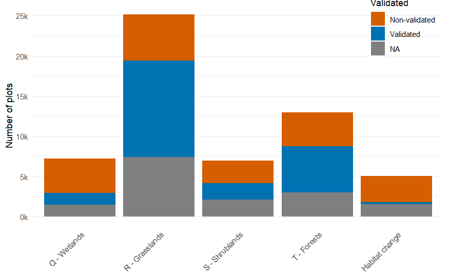

```r
plot_plots <- data_validated_plots %>%
  mutate(EUNIS = forcats::fct_relevel(EUNIS, "Change", after = Inf)) %>%
  count(EUNIS, valid_status, name = "n") %>%
  ggplot(aes(x = EUNIS, y = n, fill = valid_status)) +
  geom_col(position = position_stack()) +
  xlab(NULL) + ylab("Number of plots") +
  scale_y_continuous(labels = label_number(scale = 1e-3, suffix = "k")) +
  scale_fill_manual(values = c("not_valid" = "#D55E00", "valid" = "#0072B2",
                               "NA" = "#828282"),
                    labels = c("not_valid" = "Non-validated",
                               "valid"     = "Validated",
                               "NA"        = "NA"),
                    name = "Validated") +
  scale_x_discrete(
    breaks = c("Q", "R", "S", "T", "Change"),
    labels = function(x) {
      x <- ifelse(x == "Q", "Q - Wetlands", x)
      x <- ifelse(x == "R", "R - Grasslands", x)
      x <- ifelse(x == "S", "S - Shrublands", x)
      x <- ifelse(x == "T", "T - Forests", x)
      x <- ifelse(x == "Change", "Habitat change", x)
      x
      }
    ) +
  theme_minimal() + theme(legend.position = c(0.9, 0.9)) +
  theme(axis.text.x = element_text(angle = 45, hjust = 1)) +
  theme(panel.grid.major.x = element_blank(),
        panel.grid.minor.x = element_blank())
plot_plots
```

```r
europe_bbox_3035 <- st_bbox(
  c(
    xmin = 2500000,
    ymin = 1400000,
    xmax = 6500000,
    ymax = 5500000
  ),
  crs = st_crs(3035)
)

world <- ne_countries(scale = "medium", returnclass = "sf")
world_3035 <- st_transform(world, 3035)
points_3035 <- st_as_sf(
  data_validated_clean,
  coords = c("Lon_updated", "Lat_updated"),
  crs = 4326
) |>
  st_transform(3035)

world_3035_crop <- st_crop(world_3035, europe_bbox_3035)

plots_3035 <- st_as_sf(
  data_validated_plots,
  coords = c("Lon_updated", "Lat_updated"),
  crs = 4326
) |>
  st_transform(3035)
```

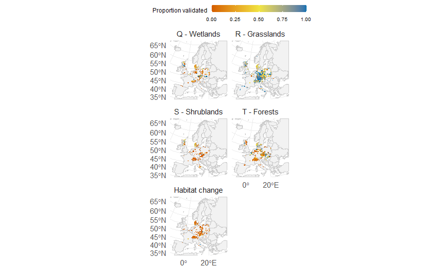

```r
# 1) Create a regular grid over your bbox
cell_km <- 50
grid_3035 <- st_make_grid(
  europe_bbox_3035,
  cellsize = cell_km * 1000,
  what = "polygons",
  square = TRUE
) |>
  (\(g) st_sf(grid_id = seq_len(length(g)), geometry = g))()

# 2) Keep only grid cells that overlap your area of interest (optional)
grid_3035 <- st_intersection(grid_3035, st_as_sf(world_3035_crop))

plots_3035_crop <- st_crop(plots_3035, europe_bbox_3035)

# 3) Spatial join: assign each point to a grid cell
# (st_join on polygons brings grid_id onto points)
pts_with_grid <- st_join(
  plots_3035_crop %>% # points, filter only validated / invalidated
    filter(valid_status == "not_valid" | valid_status == "valid"),
  grid_3035["grid_id"],           # only keep grid_id column from grid
  left = FALSE                    # drop points outside the grid
)

# 4) Aggregate by grid_id and EUNIS category
agg <- pts_with_grid |>
  st_drop_geometry() |>
  mutate(
    # ensure EUNIS "Change" is last if you facet later (optional)
    EUNIS = fct_relevel(EUNIS, "Change", after = Inf),
    is_valid = case_when(
      valid_status == "valid" ~ 1L,
      TRUE ~ 0L
    )
  ) |>
  group_by(grid_id, EUNIS) |>
  summarise(
    n_total = n(),
    n_valid = sum(is_valid, na.rm = TRUE),
    .groups = "drop"
  ) |>
  mutate(
    prop_valid = if_else(n_total > 0, n_valid / n_total, NA_real_)
  )

# 5) Join back to grid polygons
grid_agg <- grid_3035 |>
  inner_join(agg, by = "grid_id")

map_grid_plots <- ggplot() +
  geom_sf(data = world_3035_crop, fill = "grey95", color = "grey80", linewidth = 0.2) +
  geom_sf(data = grid_agg, aes(fill = prop_valid), color = NA) +   # no borders for speed
  facet_wrap(
    ~ EUNIS,
    nrow = 3,
    ncol = 2,
    labeller = labeller(EUNIS = c("Q" = "Q - Wetlands", "R" = "R - Grasslands",
                                   "S" = "S - Shrublands", "T" = "T - Forests",
                                   "Change" = "Habitat change"))) +
  scale_fill_gradientn(
    colours = c("#D55E00", "#F0E442", "#0072B2"),    # orange → yellow → blue
    values = rescale(c(0, 0.5, 1)),
    limits = c(0, 1),
    oob = squish,
    na.value = "grey90",
    name = "Proportion validated"
  ) +
  theme_minimal() +
  theme(
    legend.position = "top",
    legend.justification = c("center", "top"),
    # Tighten the legend itself
    legend.margin = margin(t = 0, r = 0, b = 0, l = 0),
    # Pull the legend box closer to the panels (reduce bottom gap)
    legend.box.margin = margin(t = 0, r = 0, b = -6, l = 0),
    # Keep a little top plot margin so nothing clips
    plot.margin = margin(t = 6, r = 0, b = 5, l = 0),
    panel.spacing = unit(6, "pt"),
    legend.key.size = unit(0.3, "lines"),
    legend.text = element_text(size = 6),
    legend.title = element_text(size = 7)
  ) +
  coord_sf(expand = FALSE) +
  guides(
  fill = guide_colorbar(
    barwidth = unit(4, "cm"),   # increase width
    barheight = unit(0.3, "cm"),  # keep it thin
    title.vjust = 0.8
  )
)
map_grid_plots
```

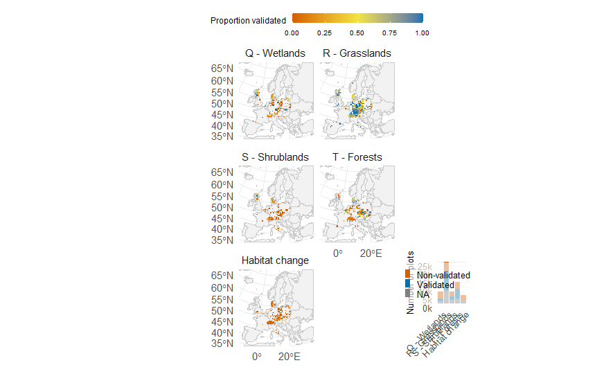

```r
plot_plots_inset <- plot_plots +
  theme(
    aspect.ratio = 3/2,        # height / width  → tall & thin (try 3/1, 4/1, 5/1)
    plot.margin  = margin(0, 0 , 0, 0),
    axis.text.x  = element_text(angle = 45, size = 8, vjust = 1, hjust = 1),
    axis.text.y  = element_text(size = 8, vjust = 1, hjust = 1),
    axis.title.y = element_text(size = 8),
    legend.title = element_blank(),
    legend.text  = element_text(size = 8),
    legend.key.size = unit(6, "pt"),

    # 🔹 Put legend inside, top-right of inset
    legend.position = c(1.4, 0.98),
    legend.justification = c(1, 1),

    # 🔹 Semi-transparent background helps readability
    legend.background = element_rect(fill = alpha("white", 0.6), color = NA)
  ) +
  coord_cartesian(clip = "off", expand = FALSE)

map_plots_with_inset <- map_grid_plots +
  inset_element(
    plot_plots_inset,
    left   = 0.45,
    right  = 0.97,
    bottom = -0.05,
    top    = 0.3,
    align_to = "panel"
  )

map_plots_with_inset +
  theme(plot.margin = margin(1, 1, 1, 1))

ggsave(here("output", "figures", "manuscript", "fig4.jpeg"),
       dpi = 300, width = 5, height = 8)
```

# (Appendix 10): Maps + graph validated obs

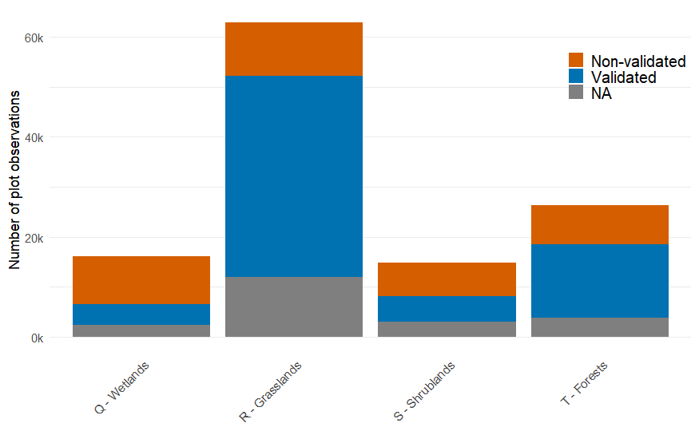

```r
plot_obs <- data_validated_clean %>%
  count(EUNIS1, valid_Landsat, name = "n") %>%
  ggplot(aes(x = EUNIS1, y = n, fill = valid_Landsat)) +
  geom_col(position = position_stack()) +
  xlab(NULL) + ylab("Number of plot observations") +
  scale_y_continuous(labels = label_number(scale = 1e-3, suffix = "k")) +
  scale_fill_manual(values = c("FALSE" = "#D55E00", "TRUE" = "#0072B2",
                               "NA" = "#828282"),
                    labels = c("FALSE" = "Non-validated",
                               "TRUE" = "Validated",
                               "NA"        = "NA"),
                     name = "Validated") +
  scale_x_discrete(
    labels = function(x) {
      x <- ifelse(x == "Q", "Q - Wetlands", x)
      x <- ifelse(x == "R", "R - Grasslands", x)
      x <- ifelse(x == "S", "S - Shrublands", x)
      x <- ifelse(x == "T", "T - Forests", x)
      x
      }
    ) +
  theme_minimal() + theme(legend.position = c(0.9, 0.8)) +
  theme(axis.text.x = element_text(angle = 45, hjust = 1)) +
  theme(panel.grid.major.x = element_blank(),
        panel.grid.minor.x = element_blank(),
        legend.title = element_blank(),
        legend.text  = element_text(size = 12),
        legend.key.size = unit(12, "pt"))
plot_obs
```

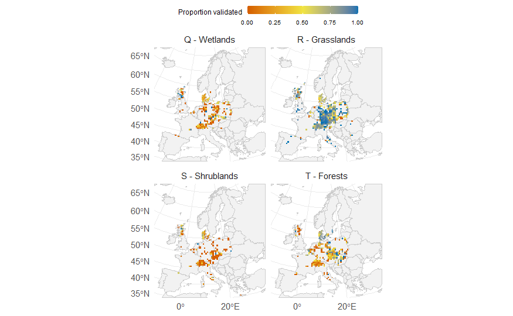

```r
# 1) Create a regular grid over your bbox
cell_km <- 50
grid_3035 <- st_make_grid(
  europe_bbox_3035,
  cellsize = cell_km * 1000,
  what = "polygons",
  square = TRUE
) |>
  (\(g) st_sf(grid_id = seq_len(length(g)), geometry = g))()

# 2) Keep only grid cells that overlap your area of interest (optional)
grid_3035 <- st_intersection(grid_3035, st_as_sf(world_3035_crop))

points_3035_crop <- st_crop(points_3035, europe_bbox_3035)

# 3) Spatial join: assign each point to a grid cell
# (st_join on polygons brings grid_id onto points)
pts_with_grid <- st_join(
  points_3035_crop %>% # points, filter only validated / invalidated
    filter(valid_Landsat == "TRUE" | valid_Landsat == "FALSE"),
  grid_3035["grid_id"],           # only keep grid_id column from grid
  left = FALSE                    # drop points outside the grid
)

# 4) Aggregate by grid_id and EUNIS category
agg <- pts_with_grid |>
  st_drop_geometry() |>
  mutate(
    is_valid = case_when(
      valid_Landsat== "TRUE" ~ 1L,
      TRUE ~ 0L
    )
  ) |>
  group_by(grid_id, EUNIS1) |>
  summarise(
    n_total = n(),
    n_valid = sum(is_valid, na.rm = TRUE),
    .groups = "drop"
  ) |>
  mutate(
    prop_valid = if_else(n_total > 0, n_valid / n_total, NA_real_)
  )

# 5) Join back to grid polygons
grid_agg <- grid_3035 |>
  inner_join(agg, by = "grid_id")

map_obs_plots <- ggplot() +
  geom_sf(data = world_3035_crop, fill = "grey95", color = "grey80", linewidth = 0.2) +
  geom_sf(data = grid_agg, aes(fill = prop_valid), color = NA) +   # no borders for speed
  facet_wrap(
    ~ EUNIS1,
    nrow = 3,
    ncol = 2,
    labeller = labeller(EUNIS1 = c("Q" = "Q - Wetlands", "R" = "R - Grasslands",
                                   "S" = "S - Shrublands", "T" = "T - Forests"))) +
  scale_fill_gradientn(
    colours = c("#D55E00", "#F0E442", "#0072B2"),    # orange → yellow → blue
    values = rescale(c(0, 0.5, 1)),
    limits = c(0, 1),
    oob = squish,
    na.value = "grey90",
    name = "Proportion validated"
  ) +
  theme_minimal() +
  theme(
    legend.position = "top",
    legend.justification = c("center", "top"),
    # Tighten the legend itself
    legend.margin = margin(t = 0, r = 0, b = 0, l = 0),
    # Pull the legend box closer to the panels (reduce bottom gap)
    legend.box.margin = margin(t = 0, r = 0, b = -6, l = 0),
    # Keep a little top plot margin so nothing clips
    plot.margin = margin(t = 6, r = 0, b = 5, l = 0),
    panel.spacing = unit(6, "pt"),
    legend.key.size = unit(0.3, "lines"),
    legend.text = element_text(size = 6),
    legend.title = element_text(size = 7)
  ) +
  coord_sf(expand = FALSE) +
  guides(
  fill = guide_colorbar(
    barwidth = unit(4, "cm"),   # increase width
    barheight = unit(0.3, "cm"),  # keep it thin
    title.vjust = 0.8
  )
)
map_obs_plots
```

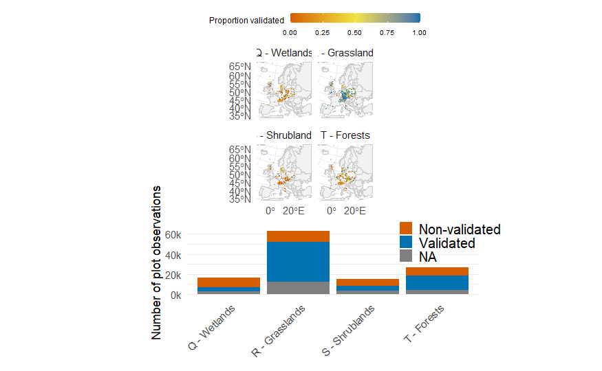

```r
(map_obs_plots /
(
  (plot_spacer() | plot_obs | plot_spacer()) +
    plot_layout(widths = c(1, 3, 1))    # ← side padding : middle column is the plot
)
)  +
  plot_layout(heights = c(4, 2)) +
  theme(plot.margin = margin(1, 1, 1, 1))
ggsave(here("output", "figures", "manuscript", "appendix10.jpeg"),
       dpi = 300, width = 5, height = 8)
```

# (Fig 3) Plots most influential variables

In these plots, include only obs where valid_Landsat == T or valid_Landsat == F, not obs where valid is NA. I.e. include obs where we had data from all predictors, and where able to get a prediction from the RF models.

```r
plot1_Landsat <- data_validated_clean %>%
  mutate(EUNIS1 = factor(EUNIS1, levels = c("Q", "R", "S", "T"))) %>%
  filter(!is.na(valid_Landsat)) %>%
  left_join(data_validation %>%
              select(PlotObservationID, NDMI_max)) %>%
  distr_plot("NDMI_max", "Maximum NDMI", grey = F) +
  theme(plot.margin = margin(2, 2, 2, 2)) +
  scale_x_discrete(limits = c("T", "S", "R", "Q"))
plot2_Landsat <- data_validated_clean %>%
  mutate(EUNIS1 = factor(EUNIS1, levels = c("Q", "R", "S", "T"))) %>%
  filter(!is.na(valid_Landsat)) %>%
  left_join(data_validation %>%
              select(PlotObservationID, SAVI_avg_value_03)) %>%
  distr_plot("SAVI_avg_value_03",
             "SAVI at greening", grey = F) +
  theme(axis.title.y = element_blank(),
        axis.text.y  = element_blank(),
        axis.ticks.y = element_blank()) +
  theme(plot.margin = margin(2, 2, 2, 2)) +
  scale_x_discrete(limits = c("T", "S", "R", "Q"))
plot3_Landsat <- data_validated_clean %>%
  mutate(EUNIS1 = factor(EUNIS1, levels = c("Q", "R", "S", "T"))) %>%
  filter(!is.na(valid_Landsat)) %>%
  left_join(data_validation %>%
              select(PlotObservationID, SAVI_diff_pos_march_value)) %>%
  distr_plot("SAVI_diff_pos_march_value",
             "Difference in SAVI between peak and greening",
             grey = F) +
  theme(plot.margin = margin(2, 2, 2, 2)) +
  scale_x_discrete(limits = c("T", "S", "R", "Q"))
plot4_Landsat <- data_validated_clean %>%
  mutate(EUNIS1 = factor(EUNIS1, levels = c("Q", "R", "S", "T"))) %>%
  filter(!is.na(valid_Landsat)) %>%
  left_join(data_validation %>%
              select(PlotObservationID, NDVI_diff_pos_march_value)) %>%
  distr_plot("NDVI_diff_pos_march_value",
             "Difference in NDVI between peak and greening",
             grey = F)  +
  theme(axis.title.y = element_blank(),
        axis.text.y  = element_blank(),
        axis.ticks.y = element_blank()) +
  theme(plot.margin = margin(2, 2, 2, 2)) +
  scale_x_discrete(limits = c("T", "S", "R", "Q"))
plot5_Landsat <- data_validated_clean %>%
  mutate(EUNIS1 = factor(EUNIS1, levels = c("Q", "R", "S", "T"))) %>%
  filter(!is.na(valid_Landsat)) %>%
  left_join(data_validation %>%
              select(PlotObservationID, NDVI_auc_mar_oct)) %>%
  distr_plot("NDVI_auc_mar_oct",
             "AUC for NDVI", grey = F) +
  theme(plot.margin = margin(2, 2, 2, 2)) +
  scale_x_discrete(limits = c("T", "S", "R", "Q"))
plot6_Landsat <- data_validated_clean %>%
  mutate(EUNIS1 = factor(EUNIS1, levels = c("Q", "R", "S", "T"))) %>%
  filter(!is.na(valid_Landsat)) %>%
  left_join(data_validation %>%
              select(PlotObservationID, SAVI_auc_mar_oct)) %>%
  distr_plot("SAVI_auc_mar_oct",
             "AUC for SAVI", grey = F)  +
  theme(axis.title.y = element_blank(),
        axis.text.y  = element_blank(),
        axis.ticks.y = element_blank()) +
  theme(axis.title.y = element_blank(),
        axis.text.y  = element_blank(),
        axis.ticks.y = element_blank()) +
  theme(plot.margin = margin(2, 2, 2, 2)) +
  scale_x_discrete(limits = c("T", "S", "R", "Q"))
plot7_Landsat <- data_validated_clean %>%
  mutate(EUNIS1 = factor(EUNIS1, levels = c("Q", "R", "S", "T"))) %>%
  filter(!is.na(valid_Landsat)) %>%
  left_join(data_validation %>%
              select(PlotObservationID, NDWI_min)) %>%
  distr_plot("NDWI_min",
             "Minimum NDWI", grey = F) +
  theme(plot.margin = margin(2, 2, 2, 2)) +
  scale_x_discrete(limits = c("T", "S", "R", "Q"))
plot_for_legend <- data_validated_clean %>%
  mutate(EUNIS1 = factor(EUNIS1, levels = c("Q", "R", "S", "T"))) %>%
  filter(!is.na(valid_Landsat)) %>%
  left_join(data_validation %>%
              select(PlotObservationID, NDMI_max)) %>%
  distr_plot("NDMI_max", "Maximum NDMI", grey = FALSE) +
  guides(fill = guide_legend(), color = guide_legend()) +
  labs(fill = "EUNIS level 1", color = "EUNIS level 1") +
  theme(legend.position = "right") +
  scale_fill_manual(values = c("#0072B2", "#D55E00", "#009E73", "#CC79A7"),
                    breaks = c("Q", "R", "S", "T"),
                    labels = c("Q" = "Q - Wetlands","R" = "R - Grasslands",
                               "S" = "S - Shrublands", "T" = "T - Forests")) +
  scale_color_manual(values = c("#0072B2", "#D55E00", "#009E73", "#CC79A7"),
                     breaks = c("Q", "R", "S", "T"),
                     labels = c("Q" = "Q - Wetlands","R" = "R - Grasslands",
                               "S" = "S - Shrublands", "T" = "T - Forests")) +
  guides(fill = guide_legend(
    override.aes = list(shape = 22, size = 8,
                        fill = c("#0072B2", "#D55E00", "#009E73", "#CC79A7"),
                        color = NA, linetype = 0, alpha = 1)),
    color = "none") +
  theme(legend.text = element_text(size = 12),
        legend.title = element_text(size = 13)) +
  scale_x_discrete(limits = c("Q", "R", "S", "T"))
legend <- patchwork::wrap_elements(get_legend(plot_for_legend))
```

```r
fig3 <- (
    plot1_Landsat + theme(plot.margin = margin(2,2,2,2)) |
      plot2_Landsat + theme(plot.margin = margin(2,2,2,2))
    ) /
  (plot3_Landsat + theme(plot.margin = margin(2,2,2,2)) |
     plot4_Landsat + theme(plot.margin = margin(2,2,2,2))
   ) /
  (plot5_Landsat + theme(plot.margin = margin(2,2,2,2)) |
     plot6_Landsat + theme(plot.margin = margin(2,2,2,2))
   ) /
  (plot7_Landsat + theme(plot.margin = margin(2,2,2,2)) |
    legend
  ) +
  plot_layout(heights = c(1,1,1,1)) &
  theme(plot.margin = margin(2,2,2,2))

ggsave(here("output", "figures", "manuscript", "fig3.jpeg"), plot = fig3,
       dpi = 300, width = 7, height = 11)
```

# (Appendix 4) Plot GPS observations used for models

```r
get_full_datasets <- function(data, variables) {
  data %>%
    mutate(EUNIS1 = as.factor(EUNIS1)) %>%
    # Remove rows with missing values in predictors
    dplyr::filter(if_all(all_of(variables), ~ !is.na(.))) %>%
    # Remove all rows with wrong values of indices (not between -1 and 1)
    dplyr::filter(NDVI_max <= 1 & NDVI_min >= -1) %>%
    dplyr::filter(SAVI_max <= 1 & SAVI_min >= -1) %>%
    dplyr::filter(NDMI_max <= 1 & NDMI_min >= -1) %>%
    dplyr::filter(NDWI_max <= 1 & NDWI_min >= -1) %>%
    # Keep only rows with differences > 0 in variables
    dplyr::filter(if_all(any_of(variables[grepl("diff", variables)]),
                  ~ .x > 0)) %>%
    # Filter based on max NDWI
    mutate(valid_1_NDWI = case_when(NDWI_max > 0.3 ~ "wrong",
                                    TRUE ~ NA_character_),
           valid_1_count = rowSums(across(c(valid_1_NDWI), ~ . == "wrong"),
                                   na.rm = TRUE),
           valid_1 = if_else(valid_1_count > 0,
                             "At least 1 rule broken", "No rules broken so far")
           ) %>%
    # Keep only rows with no rules broken
    dplyr::filter(valid_1 == "No rules broken so far") %>%
    # Remove unneeded cols
    select(-starts_with("valid"))
  }
```

```r
data_GPS <- get_full_datasets(data_validation, vars_RF_months_Landsat) %>%
  left_join(data_V2025.2 %>%
              # Update coordinates
              mutate(Lon_updated = ifelse(is.na(Lon_prec), Longitude, Lon_prec),
                     Lat_updated = ifelse(is.na(Lat_prec), Latitude, Lat_prec)) %>%
              dplyr::select(PlotObservationID, Lon_updated, Lat_updated)) %>%
  mutate(GPS = case_when(`Location method` %in%
                           c("Location with GPS",
                             "Location with differential GPS") ~ TRUE,
                         !`Location method` %in%
                           c("Location with GPS",
                             "Location with differential GPS") ~ FALSE,
                         is.na(`Location method`) ~ FALSE))
```

```r
points_3035 <- st_as_sf(data_GPS,
                        coords = c("Lon_updated", "Lat_updated"),
                        crs = 4326
                        ) |>
  st_transform(3035)

points_3035_crop <- st_crop(points_3035, europe_bbox_3035)
```

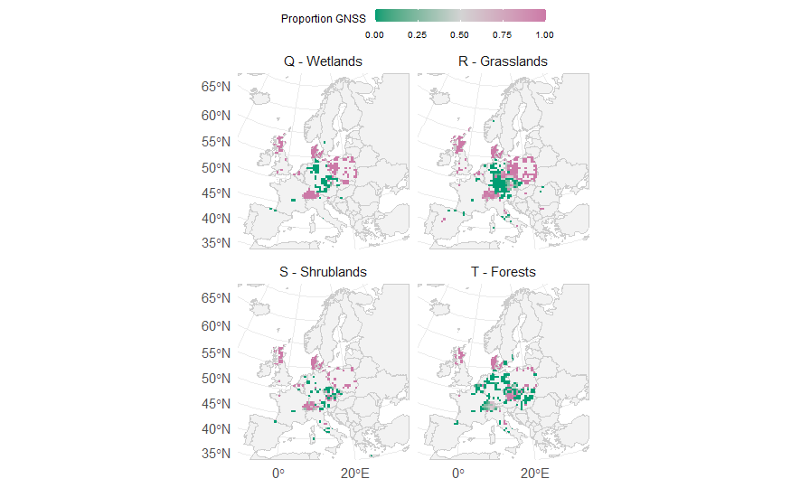

```r
# 1) Create a regular grid over your bbox
cell_km <- 50
grid_3035 <- st_make_grid(
  europe_bbox_3035,
  cellsize = cell_km * 1000,
  what = "polygons",
  square = TRUE
) |>
  (\(g) st_sf(grid_id = seq_len(length(g)), geometry = g))()

# 2) Keep only grid cells that overlap your area of interest (optional)
grid_3035 <- st_intersection(grid_3035, st_as_sf(world_3035_crop))

points_3035_crop <- st_crop(points_3035_crop, europe_bbox_3035)

# 3) Spatial join: assign each point to a grid cell
# (st_join on polygons brings grid_id onto points)
pts_with_grid <- st_join(
  points_3035_crop,
  grid_3035["grid_id"],           # only keep grid_id column from grid
  left = FALSE                    # drop points outside the grid
)

# 4) Aggregate by grid_id and EUNIS category
agg <- pts_with_grid |>
  st_drop_geometry() |>
  group_by(grid_id, EUNIS1) |>
  summarise(
    n_total = n(),
    n_GPS = sum(GPS, na.rm = TRUE),
    .groups = "drop"
  ) |>
  mutate(
    prop_GPS = if_else(n_total > 0, n_GPS / n_total, NA_real_)
  )

# 5) Join back to grid polygons
grid_agg <- grid_3035 |>
  inner_join(agg, by = "grid_id")

map_grid_GPS <- ggplot() +
  geom_sf(data = world_3035_crop, fill = "grey95", color = "grey80", linewidth = 0.2) +
  geom_sf(data = grid_agg, aes(fill = prop_GPS), color = NA) +   # no borders for speed
  facet_wrap(
    ~ EUNIS1,
    nrow = 2,
    ncol = 2,
    labeller = labeller(EUNIS1 = c("Q" = "Q - Wetlands", "R" = "R - Grasslands",
                                   "S" = "S - Shrublands", "T" = "T - Forests"))) +
  scale_fill_gradientn(
    colours = c("#009E73", "#D3D3D3", "#CC79A7"),  # green → light grey → purple
    values = rescale(c(0, 0.5, 1)),
    limits = c(0, 1),
    oob = squish,
    na.value = "grey90",
    name = "Proportion GNSS"
  ) +
  theme_minimal() +
  theme(
    legend.position = "top",
    legend.justification = c("center", "top"),
    # Tighten the legend itself
    legend.margin = margin(t = 0, r = 0, b = 0, l = 0),
    # Pull the legend box closer to the panels (reduce bottom gap)
    legend.box.margin = margin(t = 0, r = 0, b = -6, l = 0),
    # Keep a little top plot margin so nothing clips
    plot.margin = margin(t = 6, r = 0, b = 5, l = 0),
    panel.spacing = unit(6, "pt"),
    legend.key.size = unit(0.3, "lines"),
    legend.text = element_text(size = 6),
    legend.title = element_text(size = 7)
  ) +
  coord_sf(expand = FALSE) +
  guides(
  fill = guide_colorbar(
    barwidth = unit(4, "cm"),   # increase width
    barheight = unit(0.3, "cm"),  # keep it thin
    title.vjust = 0.8
  )
)
map_grid_GPS
ggsave(here("output", "figures", "manuscript", "appendix4.jpeg"),
       dpi = 300, width = 5, height = 6)
```

# HERE: (Fig 4) Maps + graph validated plots

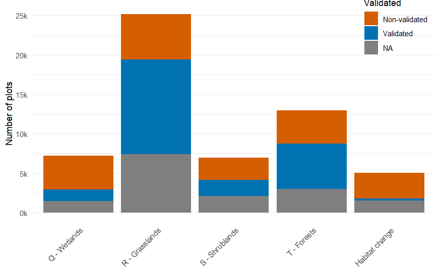

```r
plot_plots <- data_validated_plots %>%
  mutate(EUNIS = forcats::fct_relevel(EUNIS, "Change", after = Inf)) %>%
  count(EUNIS, valid_status, name = "n") %>%
  ggplot(aes(x = EUNIS, y = n, fill = valid_status)) +
  geom_col(position = position_stack()) +
  xlab(NULL) + ylab("Number of plots") +
  scale_y_continuous(labels = label_number(scale = 1e-3, suffix = "k")) +
  scale_fill_manual(values = c("not_valid" = "#D55E00", "valid" = "#0072B2",
                               "NA" = "#828282"),
                    labels = c("not_valid" = "Non-validated",
                               "valid"     = "Validated",
                               "NA"        = "NA"),
                    name = "Validated") +
  scale_x_discrete(
    breaks = c("Q", "R", "S", "T", "Change"),
    labels = function(x) {
      x <- ifelse(x == "Q", "Q - Wetlands", x)
      x <- ifelse(x == "R", "R - Grasslands", x)
      x <- ifelse(x == "S", "S - Shrublands", x)
      x <- ifelse(x == "T", "T - Forests", x)
      x <- ifelse(x == "Change", "Habitat change", x)
      x
      }
    ) +
  theme_minimal() + theme(legend.position = c(0.9, 0.9)) +
  theme(axis.text.x = element_text(angle = 45, hjust = 1)) +
  theme(panel.grid.major.x = element_blank(),
        panel.grid.minor.x = element_blank())
plot_plots
```